# Mini “exploratory report” on juvenile snowshoe hares in Bonanza Creek Experimental Forest (Long Term Ecological Research site)

ESM 206 - Environmental Data Science : Homework 4

Carmen Galaz-García

11/15/2020

## Introduction

In this report we examine the counts, weight and size measurements of juvenile snowshoe hares observed at the Bonanza Creek Experimental Forest from 1999 to 2012 (Kielland et al. 2017). In particular, we look at how the number of observations of juvenile snowshoe hares has changed over the course of the study, how weight varies across sex and sampling site and explore a possible linear relation between hares’ weight and hind foot length.

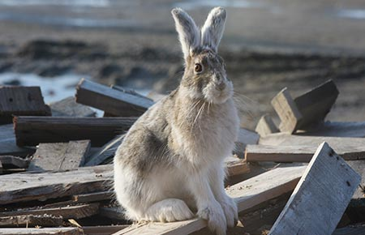

Picture credit: Jim Dau, Alaska Department of Fish and Game

## Data and analysis

Size measurements, sex and age of snowshoe hares were collected and made available by Dr. Knut Kielland and colleagues at the Bonanza Creek Experimental Forest Long Term Ecological Research (LTER) site located approximately 20 km southwest of Fairbanks, Alaska. The data contains observations of 3197 snowshoe hares obtained by capture-recapture studies conducted yearly from 1999 to 2012 in three sampling sites: Bonanza Riparian, Bonanza Mature and Bonanza Black Spruce. Out of the total observations, 378 correspond to juvenile snowshoe hares.

This report has four sections, each focused on analyzing different data related to juvenile snowshoe hares.

-**Section 1) Annual juvenile hare trap counts**  
Exploration of the counts by year of juvenile snowshoe hares.

-**Section 2) Juvenile hare weights by sex and sample site**  
Visualization and analysis of descriptive statistics for the weight of male and female juvenile snowshoe hares across the three sampling sites.

-**Section 3) Weight comparison by sex of juvenile hares**  
Analysis of the difference in average weight of male and female juvenile hares. To do so we use a Welch two-sample t-test with a significance level of 0.05 ($\alpha$) and calculate Cohen’s *d* effect size.

-**Section 4) Relationship between juvenile weight & hind foot length**  
Analysis of a possible relation between hind foot length and weight of juvenile hares, conducted using a simple linear regression model on these variables. Fitness of this model is discussed.

All analyses are in R version 4.0.2 using RStudio Version 1.3.1093.

## Exploratory findings

### Section 1) Annual juvenile hare trap counts

In this section we analyze yearly counts of juvenile snowshoe hares. In total 378 observations of juvenile snowshoe hares were recorded during the study. Sample site is not included as a variable here, though it would be it would be interesting to see if juvenile hare counts are changing equally in all sample sites.

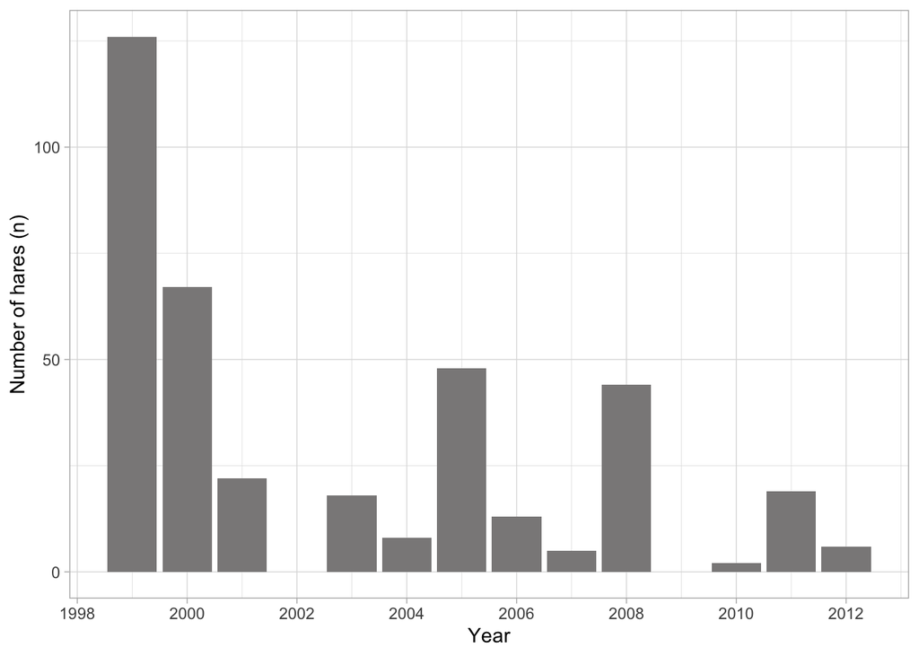

**Figure 1.** Total juvenile snowshoe hare observations (n) during each year of the study (1999-2012). Data: Kielland et al. (2017)

While these are absolute counts, these numbers are also impacted by effort. Moving forward I would suggest to conduct the trappings on the same dates every year and space these times across different seasons. For example the first two weeks of each month every year. I imagine juveniles are mostly present during Spring, but with climate change it is possible Spring weather does not come at the same dates in 2012 as in 1998, so there might be a risk of undercounting if the counts are done during a fixed period of time every year. I would also suggest to maintain the number and location of traps constant over the years.

### Section 2) Juvenile hare weights by sex and sample site

Weights (measured in grams) of male and female juvenile snowshoe hares are compared across the three sampling sites: Bonanza Black Spruce, Bonanza Mature and Bonanza Riparian. From the 378 observations of juvenile snowshoe hares recorded during the study, 7 of them did not have the hare’s weight recorded (3 females and 4 of unidentified sex).

In all three sites the average weight for male juvenile hares is greater than that of female juvenile hares. Juvenile hares were biggest at the Bonanza Black Spruce sampling site, with weight of male hares being 1073 $\pm$ 223 grams (n= 13; mean $\pm$ 1 standard deviation) and weight of female hares being 1022 $\pm$ 293 grams (n= 35). In Bonanza Mature and Bonanza Riparian the average and standard deviations of weights were similar for both female and male juvenile hares.

**Table 1.** Descriptive statistics (mean, standard deviation and sample size) at each sample site for female and male juvenile snowshoe hares. Data: Kielland et al. (2017)

| Sample site | Sex | Mean weight (g) | Standard deviation (g) | Sample size (n) |
| --- | --- | --- | --- | --- |
| Bonanza Black Spruce | female | 1022.0588 | 292.9632 | 35 |
| Bonanza Black Spruce | male | 1073.0769 | 222.6408 | 13 |
| Bonanza Black Spruce | NA | NaN | NA | 1 |
| Bonanza Mature | female | 808.1944 | 361.1235 | 36 |
| Bonanza Mature | male | 950.1250 | 314.6864 | 40 |
| Bonanza Mature | NA | 816.6667 | 307.0939 | 7 |
| Bonanza Riparian | female | 824.1496 | 255.0350 | 129 |
| Bonanza Riparian | male | 929.2727 | 349.1660 | 110 |
| Bonanza Riparian | NA | 372.0000 | 258.7856 | 7 |

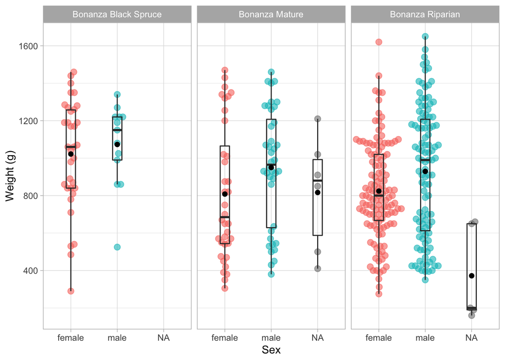

**Figure 2.** Weight (g) of juvenile snowshoe hares recorded in each sampling site, divided by sex. Red (female), blue (male) and gray (unidentified) points indicate individual observations of weight (g) of a juvenile snowshoe hare. Box endpoints indicate the 25<sup>th</sup> and 75<sup>th</sup> percentile values, the black line and black point within the box indicate the median and mean value for each species, respectively. Data: Kielland et al. (2017)

### Section 3) Weight comparison in male & female snowshoe hares

Out of 378 observations of juvenile snowshoe hares we excluded from this analysis those which did not have the hare’s sex or weight recorded, this left us with 360 observations  
(197 females and 163 males).

On average for juvenile snowshoe hares, males weigh more than females (945.86 $\pm$ 333.22 and 855.39 $\pm$ 292.25 grams, respectively; mean $\pm$ 1 standard deviation). The absolute difference in means is 90 grams, so male hares weigh 11% more than females. This difference in means is significant (Welch’s two-sample t-test: t(325.02) = 2.71, p=0.0071 < $\alpha$), though the effect size is small (Cohen’s *d* = 0.29).

**Table 2.** Descriptive statistics (mean, standard deviation, and sample size) for female and male juvenile snowshoe hares. Data: Kielland et al. (2017)

| Sex | Mean weight (g) | Standard deviation (g) | Sample size (n) |
| --- | --- | --- | --- |
| female | 855.3909 | 292.2526 | 197 |
| male | 945.8589 | 333.2151 | 163 |

### Section 4) Relationship between juvenile weight & hind foot length

In this section we explore the relationship between juvenile snowshoe hare hind foot length and weight. Out of the total 378 observations, we run the analysis on the 249 observations that include records of both hind foot length and weight.

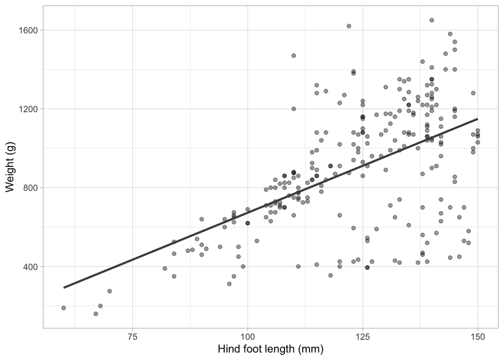

**Figure 3.** Relationship between hind foot length (mm) and weight (g) of juvenile snowshoe hares. Points indicate individual hare measurements. Linear model summary: $\beta$<sub>1</sub> = 9.52 g mm<sup>-1</sup>, p < 0.001, R<sup>2</sup> = 0.3, Pearson’s *r* = 0.55). Data: Kielland et al. (2017)

Overall a linear model of weight with respect to hind foot length does not account completely for the change in the dependent variable. Apart from data not following entirely a linear trend, further explorations show residuals are not entirely normally distributed and violate homoscedasticity (do not appear to be randomly distributed).

Notice that sex is not included as a variable in the previous analysis. If we consider observations for female and male hares separately we can see in Figure 4 that data for female hares follows a more linear trend while data for male hares tends to spread out more. It would be interesting to consider a linear model for each of these groups separately.

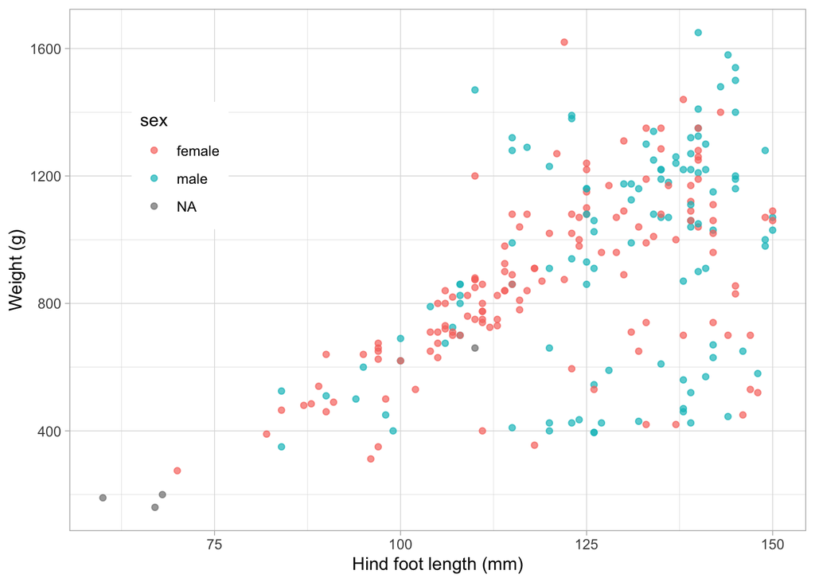

**Figure 4.** Relationship between hind foot length (mm) and weight (g) of juvenile snowshoe hares divided by sex. Red (female), blue (male) and gray (unidentified) points indicate individual observations of juvenile snowshoe hares. Data: Kielland et al. (2017)

## Summary

Next steps:

- Make a finer analysis of the count of juvenile hares that takes into account the month of the observation and not only the year.
- Analyze whether the difference in average weight between the different sample sites is significant. A one-way ANOVA could be used. though given the difference in sample sizes at each site further analysis might be needed.
- Include sex variable in the linear analysis of weight as a variable of hind foot or analyze female and male hares separately.

## Citations

Kielland, K., F.S. Chapin, R.W. Ruess, and Bonanza Creek LTER. 2017. Snowshoe hare physical data in Bonanza Creek Experimental Forest: 1999-Present ver 22. Environmental Data Initiative. (https://doi.org/10.6073/pasta/03dce4856d79b91557d8e6ce2cbcdc14) (Accessed 2020-11-19).

Teddy. Palmer penguin sizes: exploratory report. (Accessed 2020-11-20)